# MODEL MODULE: MULTIPLE OUTPUTS

This example showcases the modeling of the deflection of a simply supported beam subjected to a uniform random load at several points along its length.

## INITIALIZE UQ[PY]LAB

### Package imports

```python
from uqpylab import sessions, display_util
import numpy as np
import matplotlib.pyplot as plt
```

### Initialize common plotting parameters

```python
display_util.load_plt_defaults()
uq_colors = display_util.get_uq_color_order()
```

### Start a remote UQCloud session

```python
# Start the session
mySession = sessions.cloud()
# (Optional) Get a convenient handle to the command line interface
uq = mySession.cli
# Reset the session
mySession.reset()
```

```
Processing .
```

```
.
```

```
 done!

 uqpylab.sessions :: INFO     :: This is UQ[py]Lab, version 1.00, running on https://uqcloud.ethz.ch.
                                 UQ[py]Lab is free software, published under the open source BSD 3-clause license.
                                 To request special permissions, please contact:
                                  - Stefano Marelli (marelli@ibk.baug.ethz.ch).
                                 A new session (db983c37b976453facbd89921f56ad81) started.
```

```
 uqpylab.sessions :: INFO     :: Reset successful.
```

### Set the random seed for reproducibility

```python
uq.rng(100,'twister');
```

## COMPUTATIONAL MODEL

The simply supported beam model is shown in the following figure:

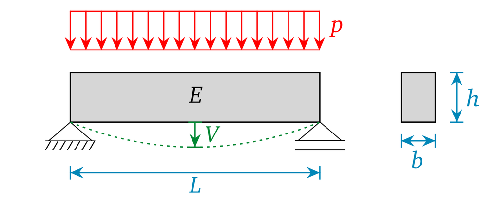

The (negative) deflection of the beam at any longitudinal coordinate $s$ is given by:

$$V(s) = -\frac{p \,s (L^3 - 2\, s^2 L + s^3) }{2E b h^3}$$

This computation is carried out by the function `simply_supported_beam_9points`. The function evaluates the inputs gathered in the $N \times M$ matrix X, where $N$ and $M$ are the numbers of realizations and inputs, respectively. The inputs are given in the following order:

- $b$: beam width $(m)$
- $h$: beam height $(m)$
- $L$: beam length $(m)$
- $E$: Young's modulus $(Pa)$
- $p$: uniform load $(N/m)$

The function returns the beam deflection $V(s_i)$ at nine equally-spaced points along the length $s_i = i \cdot L/10, \; i=1,\ldots,9.$

Create a MODEL object from the `simply_supported_beam_9points` function:

```python
ModelOpts = {
    'Type': 'Model',
    'ModelFun': 'simply_supported_beam_9points.model',
    'isVectorized': 'true'
}

myModel = uq.createModel(ModelOpts)
```

## PROBABILISTIC INPUT MODEL

The simply supported beam model has five independent input parameters modeled by lognormal random variables. The parameters of the distributions are given in the following table:

[output not shown]

Define an INPUT object with the following marginals:

```python
InputOpts = {
    'Marginals': [
        {
        'Name': 'b', # beam width
        'Type': 'Lognormal',
        'Moments': [0.15, 0.0075] # (m)
        },
        {
        'Name': 'h', # beam height
        'Type': 'Lognormal',
        'Moments': [0.3, 0.015] # (m)
        },
        {
        'Name': 'L', # beam length
        'Type': 'Lognormal',
        'Moments': [5, 0.05] # (m)
        },
        {
        'Name': 'E', # Young's modulus
        'Type': 'Lognormal',
        'Moments': [3e10, 4.5e9] # (Pa)
        },
        {
        'Name': 'p', # uniform load
        'Type': 'Lognormal',
        'Moments': [1e4, 1e3] # (N/m)
        }]
}
```

Create an INPUT object based on the specified marginals:

```python
myInput = uq.createInput(InputOpts)
```

## VISUALIZATION OF MODEL RESPONSES

Generate five sample points:

```python
X = uq.getSample(N=5,Method='LHS')
```

Evaluate the corresponding computational model responses:

```python
Y = uq.evalModel(myModel,X)
```

The output |Y| is a $N \times N_{out}$ and consists of five realizations $(N = 5)$, each with $N_{\mathrm{out}} = 9$ values:

```python
Ysize = Y.shape
Ysize
```

```
(5, 9)
```

```python
myColors = uq_colors[Ysize[0]]
li = np.arange(0,1.01,0.1)  # use normalized positions
```

Loop over the realizations and plot with a different color:

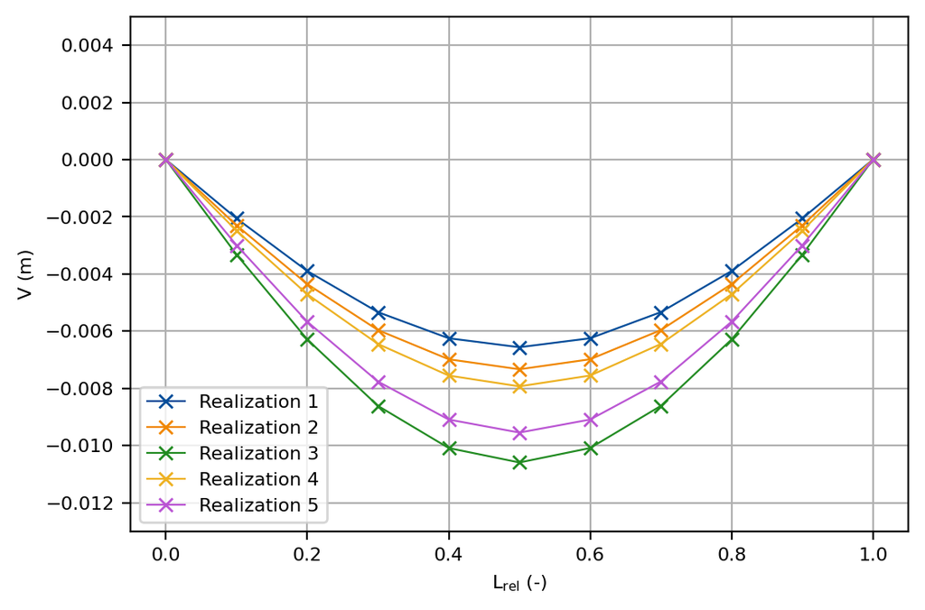

```python
fig, ax = plt.subplots()

for ii in range(Ysize[0]):
    YY = np.concatenate(([0], Y[ii,:], [0]))
    ax.plot(li, YY, 'x-', color=uq_colors[ii], label=f'Realization {ii+1}')

ax.set_ylim(-0.013, 0.005)
ax.set_xlabel('$\\mathrm{L_{rel}}$ (-)')
ax.set_ylabel('$\\mathrm{V}$ (m)')
ax.legend()
plt.show()
```

## Terminate the remote UQCloud session

```python
mySession.quit()
```

```
 uqpylab.sessions :: INFO     :: Session db983c37b976453facbd89921f56ad81 terminated.
```

```
True
```